# Assignment 1

CE7412: Computational and Systems Biology

author: Siyue Zhang

date: 2023-02-06

# Question 1

**1. Download the Ecoli bacterial genome sequences by using: library(“BSgenome.Ecoli.NCBI.20080805”) and selects the smallest of the sequences to answer the following:**

```r
library("BSgenome.Ecoli.NCBI.20080805")
```

The smallest sequence, NC_000913, has 4639675 neucleotides.

```r
seqlens <- seqlengths(Ecoli)
target <- seqlens[which.min(seqlens)]
target
```

```
## NC_000913
##   4639675
```

```r
seq <- Ecoli$NC_000913
seq
```

```
## 4639675-letter DNAString object
## seq: AGCTTTTCATTCTGACTGCAACGGGCAATATGTCTC...ATCACCAAATAAAAAACGCCTTAGTAAGTATTTTTC
```

**a. Compute neucleotide probabilities $p(X)$ and dinucleotide probabilities $p(XY)$ where $X,Y \in \Omega_{DNA}$ and $Y$ follows $X$.**

Neucleotide probabilities are calculated as follows:

```r
p <- letterFrequency(seq, c("A", "C", "G", "T"), as.prob = TRUE)
p
```

```
##         A         C         G         T
## 0.2461871 0.2542320 0.2536650 0.2459159
```

Dinucleotide probabilities are calculated as follows:

```r
pp <- dinucleotideFrequency(seq, as.prob = TRUE)
pp
```

```
##         AA         AC         AG         AT         CA         CC         CG
## 0.07282193 0.05531897 0.05127020 0.06677603 0.07008014 0.05855433 0.07471861
##         CT         GA         GC         GG         GT         TA         TC
## 0.05087879 0.05760038 0.08274956 0.05822327 0.05509180 0.04568446 0.05760922
##         TG         TT
## 0.06945294 0.07316936
```

**b. Determine the entropy and the divergence of nucleotides and dinucleotides.**

```r
H = 0
for (X in 1:4)
  H = H - p[X]*log(p[X])
H
```

```
##        A
## 1.386169
```

Neucleotide entropy = 1.386169

```r
D = 0
for (i in 1:4)
  D = D + p[i]*log(4*p[i])
D
```

```
##            A
## 0.0001251216
```

Neucleotide divergene = 0.0001251216

```r
HH = 0
for (i in 1:16)
    HH = HH - pp[i]*log(pp[i])
HH
```

```
##       AA
## 2.759576
```

Dinucleotide entropy = 2.759576

```r
D = 0
for (i in 1:16)
  D = D + pp[i]*log(16*pp[i])
D
```

```
##        AA
## 0.0130129
```

Dinucleotide divergene = 0.0130129

**c. Find the conditional probabilities** $p(Y|X)$.

```r
pp = matrix(pp,4,4,TRUE)
tpp = as.table(pp)
colnames(tpp) = c("A", "C", "G", "T")
rownames(tpp)= c("A", "C", "G", "T")
names(attributes(tpp)$dimnames) = c("X", "Y")
tpp
```

```
##    Y
## X            A          C          G          T
##   A 0.07282193 0.05531897 0.05127020 0.06677603
##   C 0.07008014 0.05855433 0.07471861 0.05087879
##   G 0.05760038 0.08274956 0.05822327 0.05509180
##   T 0.04568446 0.05760922 0.06945294 0.07316936
```

Conditional Probabilities (nucleotides) are as follows:

```r
cp = matrix(0, 4, 4)
for (i in 1:4)
  for (j in 1:4)
    cp[j,i] = pp[i,j]/p[i]
tcp = as.table(cp)
colnames(tcp) = c("A", "C", "G", "T")
rownames(tcp) = c("A", "C", "G", "T")
names(attributes(tcp)$dimnames) = c("X", "Y")
tcp
```

```
##    Y
## X           A         C         G         T
##   A 0.2957992 0.2756542 0.2270727 0.1857727
##   C 0.2247030 0.2303185 0.3262160 0.2342639
##   G 0.2082571 0.2938993 0.2295282 0.2824255
##   T 0.2712410 0.2001274 0.2171833 0.2975381
```

**d. Using following definitions, find mutual information $M(XY)$ and conditional entropy $H(Y|X)$ of the dinucleotides.**

```r
M = 0
for (i in 1:4)
  for (j in 1:4)
    M = M + tpp[i,j]*log(tpp[i,j]/(p[i]*p[j]))
M
```

```
##          A
## 0.01276266
```

Mutual information $M(XY)$ = 0.01276266

```r
H = 0
for (i in 1:4)
  for (j in 1:4)
    H = H - tpp[i,j]*log(cp[j,i])
H
```

```
## [1] 1.373407
```

Conditional entropy $H(Y|X)$ = 1.373407

**e. Using the above definitions in (d), prove that**

equation 1: $$
$$\begin{align*}
M(XY) & = \sum_{X,Y\in\Omega}{p(XY)\log(\frac{p(XY)}{p(X)p(Y)})} \\
& = \sum_{X,Y\in\Omega}{p(XY)\log(p(XY))} -
\sum_{X,Y\in\Omega}{p(XY)\log(p(X))} -
\sum_{X,Y\in\Omega}{p(XY)\log(p(Y))} \\
& = \sum_{X,Y\in\Omega}{p(XY)\log(p(XY))} -
2\sum_{X\in\Omega}\sum_{Y\in\Omega}{p(XY)\log(p(X))}\\
& = \sum_{X,Y\in\Omega}{p(XY)\log(p(XY))} -
2\sum_{X\in\Omega}{p(X)\log(p(X))}\\
& = -H(XY) + 2H(X)\\
\end{align*}$$

$$equation 2:$$
$$\begin{align*}
H(Y|X) & = -\sum_{X,Y\in \Omega}{p(XY)\log(p(Y|X))}\\
& = -\sum_{X,Y\in \Omega}{p(XY)\log(\frac{p(XY)}{p(X)})}\\
& = -\sum_{X,Y\in \Omega}{p(XY)\log(p(XY))} + \sum_{X,Y\in
\Omega}{p(XY)\log(p(X))}\\
& = -\sum_{X,Y\in \Omega}{p(XY)\log(p(XY))} +
\sum_{X\in\Omega}\sum_{Y\in\Omega}{p(XY)\log(p(X))}\\
& = -\sum_{X,Y\in\Omega}{p(XY)\log(p(XY))} +
\sum_{X\in\Omega}{p(X)\log(p(X))}\\
& = H(XY) - H(X)
\end{align*}$$
$$

**f. Find $M(XY)$ and $H(Y|X)$ for the sequence by using the equations in part (e). Comment on differences if any with those values obtained in part (d).**

$2H(X)-H(XY)$ = 0.01276266

```r
H = 0
for (X in 1:4)
  H = H - p[X]*log(p[X])

HH = 0
for (i in 1:4)
  for (j in 1:4)
    HH = HH - pp[i,j]*log(pp[i,j])

2*H-HH
```

```
##          A
## 0.01276266
```

$H(XY)-H(X)$=1.373407

```r
HH - H
```

```
##        A
## 1.373407
```

There is no difference found as $2H(X)-H(XY) = M(XY)$ and $H(XY)-H(X) = H(Y|X)$.

# Question 2

**Download the Worm genome sequences by using: library(BSgenome.Celegans.UCSC.ce2) and select the chrM sequence to answer the following:**

```r
library("BSgenome.Celegans.UCSC.ce2")
```

**Model the sequence with (i) an independent model of sequences, (ii) a first-order Markov chain, and (iii) a second order Markov chain.**

```r
seq = Celegans$chrM
seq
```

```
## 13794-letter DNAString object
## seq: CAGTAAATAGTTTAATAAAAATATAGCATTTGGGTT...TATTTATAGATATATACTTTGTATATATCTATATTA
```

```r
pC = letterFrequency(seq, c("C"), as.prob = TRUE)
pC
```

```
##          C
## 0.08880673
```

```r
stateseq = function (s) {
  vec = strsplit(s, "")[[1]]  # split the string into characters
  for (i in 1:length(vec)) {
    if (vec[i] == "A") vec[i] = 1;
    if (vec[i] == "T") vec[i] = 2;
    if (vec[i] == "G") vec[i] = 3;
    if (vec[i] == "C") vec[i] = 4;
  }
  st = as.numeric(vec)
  return(st)
}

dna = as.character(seq)
st = stateseq(dna)
```

**a. Compute model parameters for each model**

- Independent model:

```r
independent_model = function(st, ns) {
  nx = vector(ns, mode='integer')
  n = length(st)

  for (i in 1:n)
    nx[st[i]] = nx[st[i]] + 1

  px = nx/n

  loglik = log(1)
  for (i in 1:ns)
    loglik = loglik + nx[i]*log(px[i])

  return(list(px, loglik))
}
ind_model = independent_model(st, 4)

ind_model
```

```
## [[1]]
## [1] 0.31426707 0.44794838 0.14897782 0.08880673
##
## [[2]]
## [1] -16858.75
```

A: 0.31426707, T: 0.44794838, G: 0.14897782, C: 0.08880673

Log Likelihood = -16858.75

- First-order Markov model:

```r
markov_model = function(st, ns, p1) {
  N = matrix(0, ns, ns)  # counts of transitions
  for (i in 1:length(st)-1) {
    N[st[i], st[i+1]] = N[st[i],st[i+1]] + 1
  }

  sN = rowSums(N)
  A = matrix(0, ns, ns) # state transition matrix
  for (i in 1:ns)
    for (j in 1:ns)
      A[i,j] = N[i,j]/sN[i]

  loglik = log(p1)  # prob of starting nucleotide
    for (i in 1:ns)
      for (j in 1:ns)
        loglik = loglik + N[i,j]*log(A[i,j])

  colnames(A) = c("A", "T", "G", "C")
  rownames(A) = c("A", "T", "G", "C")

  return( list(A, loglik))
}

mark_model = markov_model(st, 4, pC)

mark_model
```

```
## [[1]]
##           A         T          G          C
## A 0.3101061 0.4074758 0.18689432 0.09552377
## T 0.3147759 0.4999191 0.11522900 0.07007606
## G 0.2968370 0.3956204 0.20583942 0.10170316
## C 0.3559184 0.4171429 0.08979592 0.13714286
##
## [[2]]
##         C
## -16708.82
```

Log Likelihood = -16708.82

The transition probabilities are as follows:

```r
A = as.table(mark_model[[1]])
colnames(A) = c("A", "T", "G", "C")
rownames(A) = c("A", "T", "G", "C")
names(attributes(A)$dimnames) = c("X", "Y")
A
```

```
##    Y
## X            A          T          G          C
##   A 0.31010614 0.40747577 0.18689432 0.09552377
##   T 0.31477585 0.49991908 0.11522900 0.07007606
##   G 0.29683698 0.39562044 0.20583942 0.10170316
##   C 0.35591837 0.41714286 0.08979592 0.13714286
```

- Second-order Markov model:

Assume the start probability is the density of CA.

```r
dinucleotideFrequency(seq)
```

```
##   AA   AC   AG   AT   CA   CC   CG   CT   GA   GC   GG   GT   TA   TC   TG   TT
## 1344  414  810 1766  436  168  110  511  610  209  423  813 1945  433  712 3089
```

```r
pCA = dinucleotideFrequency(seq)["CA"]/sum(dinucleotideFrequency(seq))

pCA
```

```
##         CA
## 0.03161024
```

Transition probabilities for the second-order markov model:

```r
second_markov_model = function(st, ns, p1) {
  N = array(0, dim=c(ns, ns, ns))
  dimnames(N) = list(c("A", "T", "G", "C"),c("A", "T", "G", "C"),c("A", "T", "G", "C"))
  for (i in 1:length(st)-2) {
    N[st[i], st[i+1], st[i+2]] = N[st[i],st[i+1], st[i+2]] + 1
  }

  sN = apply(N, c(1,2), sum)

  A = array(0, dim=c(ns, ns, ns))
  dimnames(A) = list(c("A", "T", "G", "C"),c("A", "T", "G", "C"),c("A", "T", "G", "C"))
  for (i in 1:ns)
    for (j in 1:ns)
      for (k in 1:ns)
        A[i,j, k] = N[i,j,k]/sN[i,j]

  loglik = log(p1)
    for (i in 1:ns)
      for (j in 1:ns)
        for (k in 1:ns)
          loglik = loglik + N[i,j,k]*log(A[i,j,k])

  return( list(A, loglik))
}


second_mark_model = second_markov_model(st, 4, pCA)

second_mark_model
```

```
## [[1]]
## , , A
##
##           A         T          G         C
## A 0.3452381 0.2961495 0.35308642 0.3743961
## T 0.2906379 0.3217870 0.28932584 0.3302540
## G 0.3213115 0.3247232 0.25531915 0.3397129
## C 0.2729358 0.3209393 0.09090909 0.3928571
##
## , , T
##
##           A         T         G         C
## A 0.4032738 0.5220838 0.3604938 0.3816425
## T 0.4331276 0.4956297 0.3862360 0.4665127
## G 0.3819672 0.4920049 0.4444444 0.4545455
## C 0.3417431 0.4618395 0.5272727 0.3333333
##
## , , G
##
##           A         T         G          C
## A 0.1703869 0.1041903 0.1950617 0.08695652
## T 0.1784979 0.1142765 0.2148876 0.09468822
## G 0.2098361 0.1340713 0.1985816 0.08133971
## C 0.2431193 0.1291585 0.2545455 0.09523810
##
## , , C
##
##            A          T          G         C
## A 0.08110119 0.07757644 0.09135802 0.1570048
## T 0.09773663 0.06830690 0.10955056 0.1085450
## G 0.08688525 0.04920049 0.10165485 0.1244019
## C 0.14220183 0.08806262 0.12727273 0.1785714
##
##
## [[2]]
##        CA
## -16646.31
```

**b. Determine the most appropriate model for the chromosome**

The second order Markov model has the highest probability as calculated above (i.e., log likelihood -16646.31), it’s regarded as the most appropriate model.

**c. Determine the statistical significance of choosing**

**i. the independence model over a random sequence by chance**

$H_0$ belongs to random model, $H_1$ belongs to independence model. I use the Chi-sqaure test to compute the significance of choosing between two models.

Compute log generalized likelihood ratio:

```r
log_random = length(st)*log(1/4)

log_order = -2*(log_random - ind_model[[2]])

m_0 = 0
m_1 = 3
m = m_1-m_0

pchisq(log_order, m, lower.tail = FALSE)
```

```
## [1] 0
```

The p-value is very small close to zero, we can reject the null hypothesis strongly.

**ii. the second-order Markov model over the first-order Markov model**

$H_0$ belongs to first-order Markov model, $H_1$ belongs to second-order Markov model.

```r
log_order = -2*(mark_model[[2]] - second_mark_model[[2]])

m_0 = 15
m_1 = 63
m = m_1-m_0

pchisq(log_order, m, lower.tail = FALSE)
```

```
##            C
## 8.715738e-09
```

The p-value is very small close to zero, we can reject the null hypothesis strongly.

# Question 3

**Given an aligned pair of sequences:**

```r
x = "ATAGACGTACAGGTCGGAATCTTAAGTGAAATCGCGCGTCCAAACCCAGCTCTATTTTAGTGGT"
y = "ATAGCGGTACAGGTCCGATACTTTAGTTAATTAGCGCGTCCATACCCAGATCTATTGTAGTGGT"
```

**Use the best suitable model from part (a) to answer part (b) and (d).**

**a. By modeling nucleotide locations independently, determine whether a random model or a match model is better suited to represent the sequence pair. State the statistical significance of your answer.**

Random: Independent model

```r
independent_model = function(st, ns) {
  nx = vector(ns, mode='integer')
  n = length(st)
  for (i in 1:n)
    nx[st[i]] = nx[st[i]] + 1

  px = nx/n

  lik = 1
  for (i in 1:ns)
    lik = lik*px[i]^nx[i]

  return(list(px, lik))
}

stateseq2 = function (s) {
  vec = strsplit(s, "")[[1]]
  for (i in 1:length(vec)) {
    if (vec[i] == "A") vec[i] = 1;
    if (vec[i] == "T") vec[i] = 2;
    if (vec[i] == "G") vec[i] = 3;
    if (vec[i] == "C") vec[i] = 4;
  }
  st = as.numeric(vec)
  return(st)
}

dx = independent_model(stateseq2(x), 4)
dy = independent_model(stateseq2(y), 4)

likelihood = dx[[2]]*dy[[2]]
likelihood_rand = likelihood
likelihood_rand
```

```
## [1] 2.617059e-77
```

Likelihood = 2.617059e-77

```r
pair_stateseq = function(x,y) {
  vx = strsplit(x, "")[[1]]
  vy = strsplit(y, "")[[1]]

  v <- vector(mode="integer", length = length(vx))
  for (i in 1:length(vx)) {
    if (vx[i] == "A") {
      if (vy[i] == "A") v[i] = 1;
      if (vy[i] == "T") v[i] = 2;
      if (vy[i] == "G") v[i] = 3;
      if (vy[i] == "C") v[i] = 4;
    }
    if (vx[i] == "T") {
      if (vy[i] == "A") v[i] = 5;
      if (vy[i] == "T") v[i] = 6;
      if (vy[i] == "G") v[i] = 7;
      if (vy[i] == "C") v[i] = 8;
    }
    if (vx[i] == "G") {
      if (vy[i] == "A") v[i] = 9;
      if (vy[i] == "T") v[i] = 10;
      if (vy[i] == "G") v[i] = 11;
      if (vy[i] == "C") v[i] = 12;
    }
    if (vx[i] == "C") {
      if (vy[i] == "A") v[i] = 13;
      if (vy[i] == "T") v[i] = 14;
      if (vy[i] == "G") v[i] = 15;
      if (vy[i] == "C") v[i] = 16;
    }
  }
 v
}
```

```r
st2 = pair_stateseq(x, y)
st2[1:25]
```

```
##  [1]  1  6  1 11  4 15 11  6  1 16  1 11 11  6 16 12 11  1  2  5 16  6  6  2  1
```

Match: Independent model

```r
dxy = independent_model(st2, 16)
likelihood_match = dxy[[2]]
dxy
```

```
## [[1]]
##  [1] 0.203125 0.062500 0.000000 0.015625 0.015625 0.234375 0.015625 0.000000
##  [9] 0.000000 0.015625 0.203125 0.015625 0.031250 0.000000 0.015625 0.171875
##
## [[2]]
## [1] 2.978497e-55
```

Likelihood = 2.978497e-55

The likelihood is maximum for matched model. Hence, most appropriate model is matched independent model.

Calculate the statistical significance:

$H_0$ belongs to random model, $H_1$ belongs to match model.

```r
order = likelihood_rand/likelihood_match
order = -2*log(order)

p_value = pchisq(order, 15-6, lower.tail=FALSE)
p_value
```

```
## [1] 7.56213e-18
```

The p-value is very small close to zero, we can reject the null hypothesis strongly.

**b. Find the probability that two sequences match at i. a particular site**

$$p = \sum_{X_1=X_2 \in
\Omega}{P(X_1,X_2)} = P(AA=1) + P(TT=6) + P(GG=11) +
P(CC=16)$$

```r
agg = dxy[[1]]
p = agg[1] + agg[6] + agg[11] + agg[16]
p
```

```
## [1] 0.8125
```

The probability is 0.8125 to find two sequences match at a particular site.

**b. Find the probability that two sequences match at ii. at least 3 sites of segments of size 5**

```r
comb = function(n, x) {
  factorial(n) / factorial(n-x) / factorial(x)
}

pp = comb(5,3)*p^3*(1-p)^2 + comb(5,4)*p^4*(1-p) + comb(5,5)*p^5
pp
```

```
## [1] 0.951231
```

The probability is 0.951231.

**c. Find the length longest matching segments of the two sequences.**

```r
max_match_length = function(xx, yy) {
  l = 0
  maxl = 0
  for (i in 1:length(xx)) {
    if (xx[i] == yy[i]) l = l+1 else l = 0
    if (maxl < l) maxl = l
  }
  return(maxl)
}

y_max = max_match_length(stateseq2(x),stateseq2(y))
y_max
```

```
## [1] 9
```

Longest matching size is 9.

**d. Determine whether a well-matched segment found by allowing two mismaches in the sequence pair is statistically significant or not.**

$$P(Y_{max} \leq y_{max} -1) =
\sum_{j=k}^{y_{max}-1}(^j_k)p^{j-k}(1-p)^{k+1}$$

$$k = 2, y_{max} = 9$$

```r
k = 2

pb = 0
for (j in k:(y_max-1)){
  tmp = comb(j,k) * (p^(j-k)) * ((1-p)^(k+1))
  pb = pb + tmp
}

1-pb
```

```
## [1] 0.7706658
```

It’s not statistically significant to reject the hypothesis of two mismaches in this well-matched segment.

# Question 4

Sample sequences containing CpG islands and nonCpG islands from human chromosome 8 have been collected and are given in fasta format in ‘CpG.txt’ and ‘NonCpG.txt’ files, respectively.

```r
seqCpG =  readDNAStringSet("CpG.txt")
seqNonCpG =  readDNAStringSet("NonCpG.txt")
seqCpG
```

```
## DNAStringSet object of length 1000:
##        width seq                                            names
##    [1]   100 GCACTCTGTCGTGTGCCCGGTG...CACTTTCAGGGCCGGTAGCGA
##    [2]   100 GGCTAGGCAGCTGCAGCTGCGC...CCGGCTCCCGCCAGCTCCGTG
##    [3]   100 TGCTCTGCCTTCCCCTGCCCGG...CTCCCACCTCTCCCTGCCTGA
##    [4]   100 GACAGAGAGCCTTTGGCTGCTT...TCAGGACAGAAAGCAGGCGTT
##    [5]   100 TTAGTGGGTGCCTCCTAGGAGC...GTGGTAAGGGGGCTGGAAGAC
##    ...   ... ...
##  [996]   100 TCTAGTTCTCTCACATGGCACC...GTTCTCTCACATGGTGCCGTG
##  [997]   100 GGCAGGCGAGCGCGCTGCCCAC...ACCGCAGTCATCGCGCGGCAC
##  [998]   100 GTGAGGATGCAGGTCACGCTGC...CCTGGGCCTCCCATGGCCCCA
##  [999]   100 CGGCTGGATGAGATCACGTCTG...GCAGCTCAGCCGGCTCCTGGG
## [1000]   100 CAAGGCGAACACCAAGGACGCG...CTCCTAGGCGCTTCTTGGAAG
```

**a. Model the CpG islands and nonCPG islands with first-order Markov models. Find the parameters of the two models.**

```r
dinucCpG    = sapply(seqCpG, dinucleotideFrequency)
dinucCpG[, 1]
```

```
## AA AC AG AT CA CC CG CT GA GC GG GT TA TC TG TT
##  0  4  5  0  6 15  8 10  3 14  7  7  1  6 10  3
```

```r
dinucNonCpG = sapply(seqNonCpG, dinucleotideFrequency)
dinucNonCpG[, 1]
```

```
## AA AC AG AT CA CC CG CT GA GC GG GT TA TC TG TT
##  9  2 12  5  4  3  2  5 10  5  9 10  5  4 11  3
```

Transition probabilities of CpG islands:

```r
IslCounts  = rowSums(dinucCpG)
TI  = matrix( IslCounts, ncol = 4, byrow = TRUE)
dimnames(TI) = list(c("A", "C", "G", "T"), c("A", "C", "G", "T"))

MI = TI /rowSums(TI)
MI
```

```
##            A         C         G         T
## A 0.19310585 0.2682672 0.4020810 0.1365460
## C 0.19604171 0.3521883 0.2318162 0.2199538
## G 0.18393386 0.3163625 0.3514584 0.1482452
## T 0.09492885 0.3379264 0.3655975 0.2015473
```

Transition probabilities of nonCpG island:

```r
NonICounts = rowSums(dinucNonCpG)
TnI = matrix(NonICounts, ncol = 4, byrow = TRUE)
dimnames(TI)  = list(c("A", "C", "G", "T"), c("A", "C", "G", "T"))

MN = TnI / rowSums(TnI)
MN
```

```
##           [,1]      [,2]       [,3]      [,4]
## [1,] 0.3380813 0.1674228 0.22866769 0.2658283
## [2,] 0.3656171 0.2461656 0.04215338 0.3460640
## [3,] 0.3010176 0.2052853 0.24436794 0.2493292
## [4,] 0.2275263 0.1944961 0.24443017 0.3335474
```

**b. Using the likelihood ratios of the two models, describe a method to decide if a given sequence is a CpG island or not. Determine the maximum and minimum values of likelihood ratios for the given sequences of CpG islands and nonCpG islands.**

Using the alpha value we found, we can compute a loglikelihood score for a given sequence. If the loglikelihood score is larger than the threshold, it is regarded as CpG islands. Otherwise, it is nonCpG islands.

```r
beta  = log(MI / MN)
beta
```

```
##            A         C         G          T
## A -0.5600478 0.4714611 0.5643838 -0.6661893
## C -0.6232591 0.3581616 1.7046300 -0.4532062
## G -0.4925924 0.4324881 0.3634164 -0.5199065
## T -0.8741382 0.5524159 0.4026033 -0.5037609
```

Compute the ratio of nucleotide probabilities of the two models:

```r
freqIsl = alphabetFrequency(seqCpG, baseOnly = TRUE, collapse = TRUE)[1:4]
freqIsl / sum(freqIsl)
```

```
##       A       C       G       T
## 0.17352 0.32342 0.32417 0.17889
```

```r
freqNon = alphabetFrequency(seqNonCpG, baseOnly = TRUE, collapse = TRUE)[1:4]
freqNon / sum(freqNon)
```

```
##       A       C       G       T
## 0.30309 0.19881 0.19939 0.29871
```

```r
alpha = log((freqIsl/sum(freqIsl)) / (freqNon/sum(freqNon)))
alpha
```

```
##          A          C          G          T
## -0.5577369  0.4866022  0.4860054 -0.5127021
```

Suppose we have a sequence “ACGTTATACTACG”, the score is -0.4995709.

```r
x = "ACGTTATACTACG"
scorefun = function(x) {
  s = unlist(strsplit(x, ""))
  score = alpha[s[1]]
  if (length(s) >= 2)
    for (j in 2:length(s))
      score = score + beta[s[j-1], s[j]]
  score
}
scorefun(x)
```

```
##          A
## -0.4995709
```

```r
scores = c()
for (i in 1:length(seqCpG)){
  s = scorefun(as.character(seqCpG[i]))
  scores = c(scores, s)}
scores_CpG = scores/100
max(scores)
```

```
## [1] 59.72279
```

```r
min(scores)
```

```
## [1] -21.09602
```

CpG islands (non-length-normalized) loglikelihood scores: max 59.72279, min -21.09602

```r
scores = c()
for (i in 1:length(seqCpG)){
  s = scorefun(as.character(seqNonCpG[i]))
  scores = c(scores, s)}
scores_NonCpG = scores/100
max(scores)
```

```
## [1] 31.36811
```

```r
min(scores)
```

```
## [1] -49.47441
```

NonCpG islands (non-length-normalized) loglikelihood scores: max 31.36811, min -49.47441

**c. Plot the histograms of the length-normalized log-likelihood ratios of the sequences in both files.**

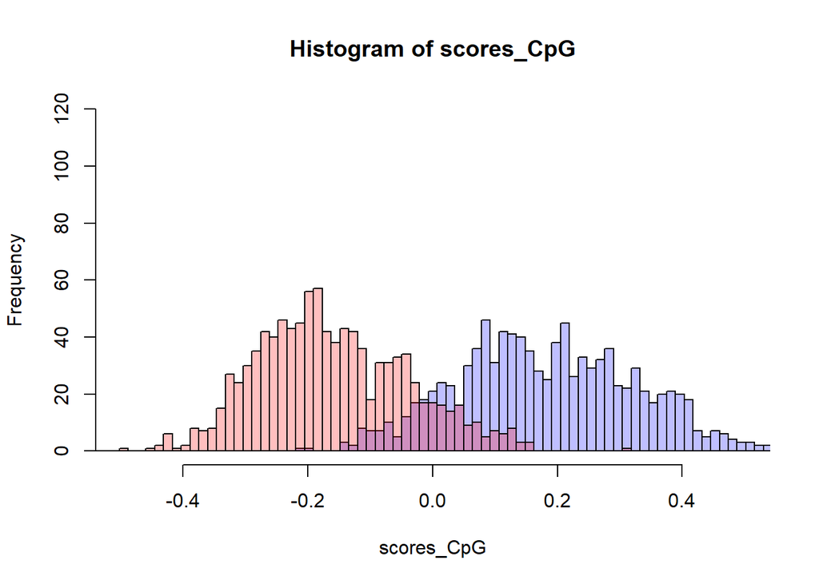

```r
br = seq(-0.7, 0.7, length.out = 100)
h1 = hist(scores_CpG,    breaks = br, plot = FALSE)
h2 = hist(scores_NonCpG, breaks = br, plot = FALSE)
plot(h1, col = rgb(0, 0, 1, 1/4), xlim = c(-0.5, 0.5), ylim=c(0,120))
plot(h2, col = rgb(1, 0, 0, 1/4), add = TRUE)
```

**d. By fitting two Gaussian functions to the histograms of CpG islands and nonCpG sequences, determine a data-driven threshold for detecting a CpG island. Evaluate the sensitivity and specificity of your method on given CpG islands or non CpG islands.**

I fit two gaussian distributions to CpG and non CpG islands as below:

```r
library("MASS")
cpg = fitdistr(scores_CpG, "normal")
cpg
```

```
##       mean           sd
##   0.181290874   0.141074391
##  (0.004461164) (0.003154519)
```

```r
noncpg = fitdistr(scores_NonCpG, "normal")
noncpg
```

```
##        mean            sd
##   -0.160422634    0.119433955
##  ( 0.003776833) ( 0.002670624)
```

The threshold for detecting a CpG island ($CutX), which is the intersection between two gaussian distributions:

```r
library(AdaptGauss)
x = Intersect2Mixtures(cpg$estimate[1],cpg$estimate[2],1,noncpg$estimate[1],noncpg$estimate[2],1)
x
```

```
## $CutX
## [1] 0.004424052
##
## $CutY
## [1] 1.288696
```

Sensitivity = Recall = TP / (TP + FN) = 0.89

```r
thre = x$CutX
TP = sum(scores_CpG>thre)
TN = sum(scores_NonCpG<thre)
FP = sum(scores_NonCpG>thre)
FN = sum(scores_CpG<thre)

Sensitivity = TP / (TP + FN)
Sensitivity
```

```
## [1] 0.89
```

Specificity = TN / (TN + FP) = 0.901

```r
Specificity = TN / (TN + FP)
Specificity
```

```
## [1] 0.901
```

# Question 5

Build a Profile HMM to represent the following multiple amino acid sequence alignment (each row represents a sequence). Consider columns with gaps >4 belonging to insert states. The aligned sequences are also given in ‘sequence_alignment.txt’ file.

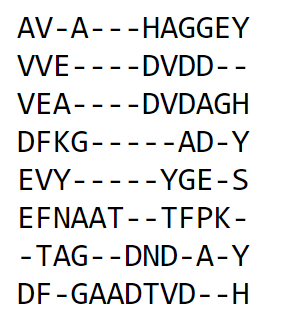

**a. Find the state transition probabilities and the emission probabilities of the model.**

```r
seqs = scan("sequence_alignment.txt",what=character())
seqs
```

```
## [1] "AV-A---HAGGEY" "VVE----DVDD--" "VEA----DVDAGH" "DFKG-----AD-Y"
## [5] "EVY-----YGE-S" "EFNAAT--TFPK-" "-TAG--DND-A-Y" "DF-GAADTVD--H"
```

```r
stateseq3 <- function(seq) {
  vec = strsplit(seq, "")[[1]]
  for (i in 1:length(vec)) {
    if (vec[i] == "A") vec[i]<-1;
    if (vec[i] == "C") vec[i]<-2;
    if (vec[i] == "D") vec[i]<-3;
    if (vec[i] == "E") vec[i]<-4
    if (vec[i] == "F") vec[i]<-5;
    if (vec[i] == "G") vec[i]<-6;
    if (vec[i] == "H") vec[i]<-7;
    if (vec[i] == "I") vec[i]<-8;
    if (vec[i] == "K") vec[i]<-9;
    if (vec[i] == "L") vec[i]<-10;
    if (vec[i] == "M") vec[i]<-11;
    if (vec[i] == "N") vec[i]<-12;
    if (vec[i] == "P") vec[i]<-13;
    if (vec[i] == "Q") vec[i]<-14;
    if (vec[i] == "R") vec[i]<-15;
    if (vec[i] == "S") vec[i]<-16;
    if (vec[i] == "T") vec[i]<-17;
    if (vec[i] == "V") vec[i]<-18;
    if (vec[i] == "W") vec[i]<-19;
    if (vec[i] == "Y") vec[i]<-20;
    if (vec[i] == "-") vec[i]<-21;
  }
  st <- as.numeric(vec)
  st
}

t(sapply(seqs, stateseq3))
```

```
##               [,1] [,2] [,3] [,4] [,5] [,6] [,7] [,8] [,9] [,10] [,11] [,12]
## AV-A---HAGGEY    1   18   21    1   21   21   21    7    1     6     6     4
## VVE----DVDD--   18   18    4   21   21   21   21    3   18     3     3    21
## VEA----DVDAGH   18    4    1   21   21   21   21    3   18     3     1     6
## DFKG-----AD-Y    3    5    9    6   21   21   21   21   21     1     3    21
## EVY-----YGE-S    4   18   20   21   21   21   21   21   20     6     4    21
## EFNAAT--TFPK-    4    5   12    1    1   17   21   21   17     5    13     9
## -TAG--DND-A-Y   21   17    1    6   21   21    3   12    3    21     1    21
## DF-GAADTVD--H    3    5   21    6    1    1    3   17   18     3    21    21
##               [,13]
## AV-A---HAGGEY    20
## VVE----DVDD--    21
## VEA----DVDAGH     7
## DFKG-----AD-Y    20
## EVY-----YGE-S    16
## EFNAAT--TFPK-    21
## -TAG--DND-A-Y    20
## DF-GAADTVD--H     7
```

```r
nseqs = length(seqs)
nchars = nchar(seqs[1])
matseq = matrix(0, nseqs, nchars)
for (i in 1:nseqs){
  stseq = stateseq3(seqs[i])
  for (j in 1:nchars)
    matseq[i,j] = stseq[j]
}
matseq
```

```
##      [,1] [,2] [,3] [,4] [,5] [,6] [,7] [,8] [,9] [,10] [,11] [,12] [,13]
## [1,]    1   18   21    1   21   21   21    7    1     6     6     4    20
## [2,]   18   18    4   21   21   21   21    3   18     3     3    21    21
## [3,]   18    4    1   21   21   21   21    3   18     3     1     6     7
## [4,]    3    5    9    6   21   21   21   21   21     1     3    21    20
## [5,]    4   18   20   21   21   21   21   21   20     6     4    21    16
## [6,]    4    5   12    1    1   17   21   21   17     5    13     9    21
## [7,]   21   17    1    6   21   21    3   12    3    21     1    21    20
## [8,]    3    5   21    6    1    1    3   17   18     3    21    21     7
```

```r
fmatseq = factor(matseq)
levels(fmatseq)
```

```
##  [1] "1"  "3"  "4"  "5"  "6"  "7"  "9"  "12" "13" "16" "17" "18" "20" "21"
```

```r
namino = length(levels(fmatseq))

ngaps <- vector("integer", nchars)
for (j in 1:nchars){
  for (i in 1:nseqs)
    if (matseq[i,j]==21)
      ngaps[j] = ngaps[j] + 1
}

gt = floor(nseqs/2)
```

number of matched states:

```r
mstate = matrix(0, nseqs, nchars)
nm = 0
for (j in 1:nchars){
  if (ngaps[j] > gt) {
    for (i in 1:nseqs)
      if (matseq[i, j] < 21)
        mstate [i, j] = 2
      else
        mstate[i, j] = 0 # no state is defined: no character within an insert state
  }
  else {
    for (i in 1:nseqs) {
      if (matseq[i,j] == 21)
        mstate[i, j] = 3
      else
        mstate[i,j] = 1
    }
    nm = nm + 1
  }
}
nm # number of matched states
```

```
## [1] 9
```

Emission probabilities are as below:

```r
emission_probabilities = function(mstate, matseq, nm) {

  ee = array(0, c(nm, 2, 20))

  for (i in 1:nseqs) {
    st = 1
    for (j in 1:nchars) {

      if (mstate[i, j] == 1)
        ee[st, mstate[i, j], matseq[i, j]] = ee[st, mstate[i, j],  matseq[i, j]] + 1
      if (mstate[i, j] == 2)
        ee[st-1, mstate[i, j], matseq[i, j]] = ee[st-1, mstate[i, j],  matseq[i, j]] + 1

      if (ngaps[j] <= gt)
        st = st + 1
    }
  }

  pe = array(0, c(nm, 2, 20))
  for (i in 1:nm)
    for (j in 1:2)
      if (sum(ee[i, j,]) != 0) pe[i, j,] = ee[i, j,]/sum(ee[i, j,])

  pe
}

pe = emission_probabilities(mstate, matseq, nm)
pem = t(pe[, 1, ]) # at match states
pei = t(pe[, 2, ]) # at insert states

rownames(pem) = rownames(pei) = c("A","C","D","E","F","G","H","I","K","L","M","N","P","Q","R","S","T","V","W","Y")
print(round(pem, 2))
```

```
##   [,1] [,2] [,3] [,4] [,5] [,6] [,7] [,8] [,9]
## A 0.14 0.00 0.33  0.4  0.0 0.14 0.14 0.29 0.00
## C 0.00 0.00 0.00  0.0  0.0 0.00 0.00 0.00 0.00
## D 0.29 0.00 0.00  0.0  0.4 0.14 0.43 0.29 0.00
## E 0.29 0.12 0.17  0.0  0.0 0.00 0.00 0.14 0.00
## F 0.00 0.38 0.00  0.0  0.0 0.00 0.14 0.00 0.00
## G 0.00 0.00 0.00  0.6  0.0 0.00 0.29 0.14 0.00
## H 0.00 0.00 0.00  0.0  0.2 0.00 0.00 0.00 0.33
## I 0.00 0.00 0.00  0.0  0.0 0.00 0.00 0.00 0.00
## K 0.00 0.00 0.17  0.0  0.0 0.00 0.00 0.00 0.00
## L 0.00 0.00 0.00  0.0  0.0 0.00 0.00 0.00 0.00
## M 0.00 0.00 0.00  0.0  0.0 0.00 0.00 0.00 0.00
## N 0.00 0.00 0.17  0.0  0.2 0.00 0.00 0.00 0.00
## P 0.00 0.00 0.00  0.0  0.0 0.00 0.00 0.14 0.00
## Q 0.00 0.00 0.00  0.0  0.0 0.00 0.00 0.00 0.00
## R 0.00 0.00 0.00  0.0  0.0 0.00 0.00 0.00 0.00
## S 0.00 0.00 0.00  0.0  0.0 0.00 0.00 0.00 0.17
## T 0.00 0.12 0.00  0.0  0.2 0.14 0.00 0.00 0.00
## V 0.29 0.38 0.00  0.0  0.0 0.43 0.00 0.00 0.00
## W 0.00 0.00 0.00  0.0  0.0 0.00 0.00 0.00 0.00
## Y 0.00 0.00 0.17  0.0  0.0 0.14 0.00 0.00 0.50
```

Transition probabilities are as below:

```r
transition_probabilities2 = function(mstate, matseq, nm) {

  aa = array(0, c((nm-1), 3, 3)) # state transition matrix: 'm', 'i' and 'd' states

  for (i in 1:nseqs) {
    st = pst = ist = 1. # position in sequence; match state; insert state
    for (j in 1:(nchars-1)) {

      if (ngaps[j] <= gt) {
        if (mstate[i, j+1] == 1 || mstate[i, j+1] == 3) {
          aa[st, mstate[i, j], mstate[i, j+1]] = aa[st, mstate[i, j], mstate[i, j+1]] + 1
          pst = j + 1
        }
        else if(mstate[i, j+1]!=0){
          aa[st, mstate[i, j], mstate[i, j+1]] = aa[st, mstate[i, j], mstate[i, j+1]] + 1
          ist = j + 1
        }
        st = st + 1
      }
      else {
        if (mstate[i,j+1] == 1 || mstate[i, j+1] == 3) { # at an end of insert state
          if (ist > pst)
            aa[st-1, mstate[i, ist], mstate[i, j+1]] = aa[st-1, mstate[i, ist], mstate[i, j+1]] + 1
          else
            aa[st-1, mstate[i, pst], mstate[i, j+1]] = aa[st-1, mstate[i, pst], mstate[i, j+1]] + 1
          pst = j+1
        }
        if (mstate[i,j+1] == 2) {
          if (ist > pst)
            aa[st-1, mstate[i, ist], mstate[i, j+1]] = aa[st-1, mstate[i, ist], mstate[i, j+1]] + 1
          else
            aa[st-1, mstate[i, pst], mstate[i, j+1]] = aa[st-1, mstate[i, pst], mstate[i, j+1]] + 1
          ist = j + 1
        }
      }

    }
  }

  pa = array(0, c((nm-1), 3, 3))
  for (i in 1:(nm-1))
    for (j in 1:3)
      if (sum(aa[i, j,])!= 0) pa[i, j,] = aa[i,j,]/sum(aa[i, j,])

  pa
}

pa = transition_probabilities2(mstate, matseq, nm)

pmat = matrix(0, 3, 3)

for (i in 1:(nm-1)) {
  print(paste("i = ", i))
  pmat = pa[i, , ]
  rownames(pmat) = colnames(pmat) = c("m", "i", "d")
  print(round(pmat, 2))
}
```

```
## [1] "i =  1"
##   m i d
## m 1 0 0
## i 0 0 0
## d 1 0 0
## [1] "i =  2"
##      m i    d
## m 0.75 0 0.25
## i 0.00 0 0.00
## d 0.00 0 0.00
## [1] "i =  3"
##     m i   d
## m 0.5 0 0.5
## i 0.0 0 0.0
## d 1.0 0 0.0
## [1] "i =  4"
##      m   i    d
## m 0.20 0.6 0.20
## i 0.33 0.5 0.17
## d 0.67 0.0 0.33
## [1] "i =  5"
##      m i    d
## m 1.00 0 0.00
## i 0.00 0 0.00
## d 0.67 0 0.33
## [1] "i =  6"
##      m i    d
## m 0.86 0 0.14
## i 0.00 0 0.00
## d 1.00 0 0.00
## [1] "i =  7"
##      m i    d
## m 0.86 0 0.14
## i 0.00 0 0.00
## d 1.00 0 0.00
## [1] "i =  8"
##      m    i    d
## m 0.43 0.43 0.14
## i 0.67 0.00 0.33
## d 1.00 0.00 0.00
```

**b. Determine the alignment and the likelihood, given by the model for the following two sequences:**

Based on the HMM profile based above, two sequences, “AVAAGDYDSY” and “TFADYYH”, are aligned as below:

```r
library(aphid)
library(ape)

seqs_a = as.AAbin(seqs)
seqs_a = as.matrix(AAStringSet(seqs))
phmm = derivePHMM(seqs_a)

alignment1 = align(list(strsplit("AVAAGDYDSY","")[[1]]), phmm)
alignment2 = align(list(strsplit("TFADYYH","")[[1]]), phmm)


print(alignment1)
```

```
##      1   2   3   4   I   5   6   7   8   9
## [1,] "A" "V" "A" "A" "G" "D" "Y" "D" "S" "Y"
```

```r
print(forward(phmm, list(strsplit("AVAAGDYDSY","")[[1]]), odds=FALSE))
```

```
## Full (log) probability of sequence given model = -22.54357
```

The log probability of of sequence given model = -22.54357.

```r
print(alignment2)
```

```
##      1   2   3   4   5   6   7   8   9
## [1,] "T" "F" "A" "-" "D" "Y" "Y" "-" "H"
```

```r
print(forward(phmm, list(strsplit("TFADYYH","")[[1]]), odds=FALSE))
```

```
## Full (log) probability of sequence given model = -17.89012
```

The log probability of of sequence given model = -17.89012.

The HMM profile is demonstrated as below:

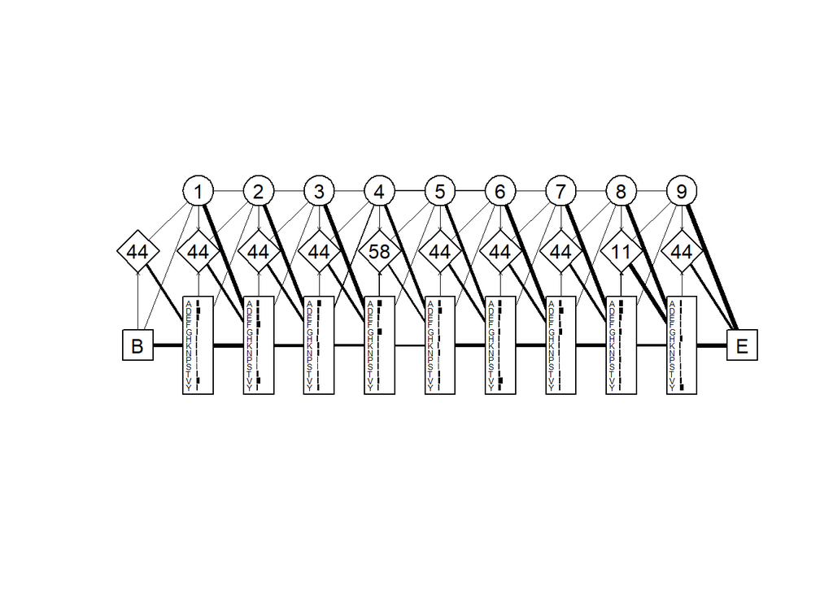

```r
plot(phmm)
```